# Decomposition of US Candy Production

brp107@scarletmail.rutgers.edu

10/7/2026

```r
library(fpp2)
candy <- read.csv("candy.csv")
candy_ts <- ts(candy$IPG3113N, start = c(1972, 1), frequency = 12)
head(candy_ts)
```

```
##          Jan     Feb     Mar     Apr     May     Jun
## 1972 74.6599 62.5737 57.5218 56.2504 56.6371 58.9318
```

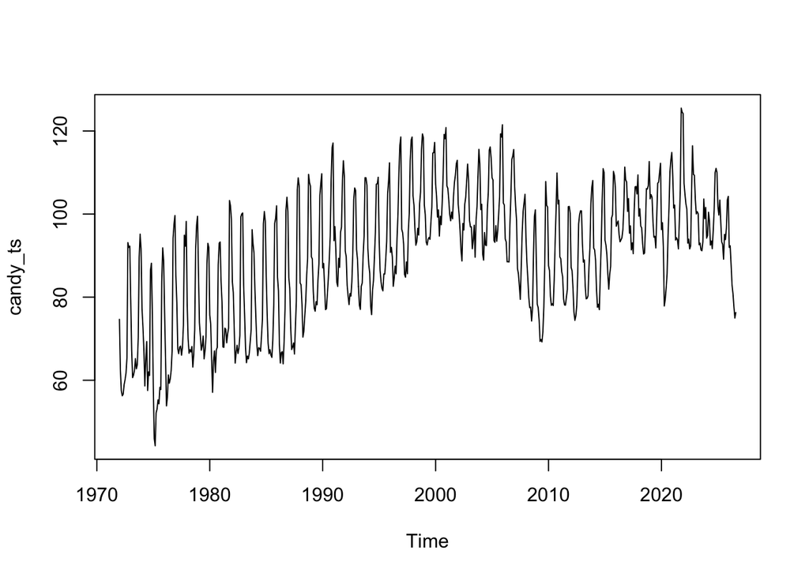

```r
plot(candy_ts)
```

**Explanation:** The plot shows two patterns that decomposition will separate. There is a long-run movement in the level, rising until about 2001, dropping in the late 2000s, recovering, and falling again at the end. There is a repeating yearly pattern with a peak every fall. The lowest value in the series is 44.22 in March 1975 and the highest is 125.50 in October 2021. Decomposition splits the series into its parts so each one can be studied on its own.

## STL Decomposition

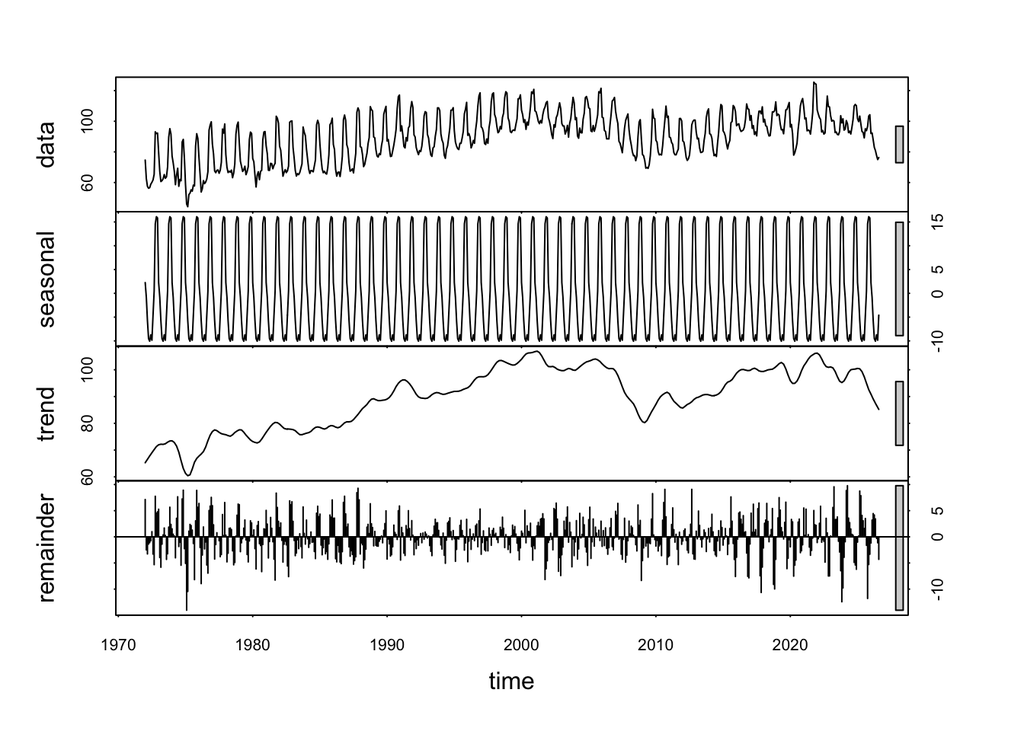

```r
stl_decomp <- stl(candy_ts,s.window ="periodic")
plot(stl_decomp)
```

```r
attributes(stl_decomp)
```

```
## $names
## [1] "time.series" "weights"     "call"        "win"         "deg"
## [6] "jump"        "inner"       "outer"
##
## $class
## [1] "stl"
```

**Explanation:** This splits the series into three components that add back up to the original data (an additive model).

- **data:** The original series.
- **seasonal:** This is the pattern that repeats every year.The seasonal pattern is identical in every year. Production is highest in October, November, and December and lowest from April through July. The climb starts in August and September, ahead of Halloween and the winter holidays, and production drops back in January.
- **trend:** The underlying growth and/or decline with seasonality is removed. The trend falls to a low of about 60 in early 1975, rises to a peak of about 107 in early 2001, and drops sharply to about 80 in early 2009. It then recovers to about 103 by 2019, dips to about 95 in early 2020, and reaches about 106 at the start of 2022. After that it declines, and it falls quickly from about 100 in early 2025 to about 85 in August 2026. The dips line up with the mid-1970s recession, the 2007 to 2009 recession, and the 2020 pandemic.
- **remainder:** The irregular part is left over. This shows the data without any leading factors. It shows mostly the raw data.

## Seasonal Adjustment

```r
seasadj(stl_decomp)
```

```
##            Jan       Feb       Mar       Apr       May       Jun       Jul
## 1972  72.40238  63.40117  63.26843  65.77610  66.70327  67.65131  70.00139
## 1973  77.25608  68.12367  66.37493  70.75490  72.50387  73.93241  72.61859
## 1974  74.99528  73.64217  73.00183  68.14970  75.04787  78.03201  67.39169
## 1975  56.20888  46.81727  49.96953  61.67790  63.14157  63.99181  64.18869
## 1976  74.13668  66.09537  59.56903  65.50060  71.34007  68.00181  70.15929
## 1977  82.90008  79.54487  73.29453  75.92580  78.04397  76.94811  75.89179
## 1978  76.05138  70.77937  72.25343  76.90760  76.86667  76.83491  73.02219
## 1979  83.72688  74.71447  76.38973  76.75350  78.34447  79.35741  75.00069
## 1980  73.44238  74.35457  70.60453  66.61540  74.82517  75.77611  71.73579
## 1981  81.68878  79.65177  73.75203  77.45460  82.61697  80.99281  78.86279
## 1982  81.47078  81.94067  78.19183  73.65350  76.67697  77.14031  76.30519
## 1983  80.60768  76.74687  73.64373  73.74110  75.88807  73.85201  76.35679
## 1984  79.51788  76.04657  74.49683  75.45420  77.91647  76.37701  76.84589
## 1985  82.82488  76.70827  74.68243  75.90580  77.42617  74.77811  75.35619
```

[output cut: 97 more lines]

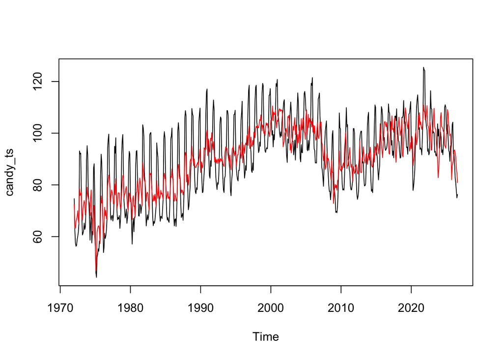

```r
plot(candy_ts)
lines(seasadj(stl_decomp), col="Red")
```

**Explanation:** This removes the seasonal component from the data, leaving the trend plus the remainder of cyclical and irregular. For example, August is normally below the trend, so the seasonally adjusted value is higher.

In the plot, the black line is the original data and the red line is the seasonally adjusted series. The red line swings far less because the yearly holiday peaks and spring dips are gone. This makes it easier to see real changes in production, such as the drops around 2008 to 2009 and in 2020, without confusing them with the normal seasonal pattern. The red line is still jagged because the remainder is left in.

## Forecast

```r
f_stl <- forecast(stl_decomp)
f_stl <- forecast(stl_decomp,h=15)
f_stl
```

```
##          Point Forecast    Lo 80     Hi 80    Lo 95     Hi 95
## Sep 2026       81.95362 76.76983  87.13741 74.02570  89.88154
## Oct 2026       96.07168 89.20789 102.93548 85.57441 106.56895
## Nov 2026       97.55904 89.35222 105.76585 85.00780 110.11027
## Dec 2026       97.29219 87.93314 106.65124 82.97876 111.60562
## Jan 2027       83.70818 73.32397  94.09239 67.82690  99.58946
## Feb 2027       80.62319 69.30631  91.94008 63.31551  97.93088
## Mar 2027       75.70403 63.52569  87.88237 57.07887  94.32919
## Apr 2027       71.92496 58.94221  84.90772 52.06955  91.78038
## May 2027       71.38449 57.64433  85.12465 50.37073  92.39825
## Jun 2027       72.73116 58.27322  87.18910 50.61964  94.84267
## Jul 2027       71.59437 56.45264  86.73610 48.43709  94.75165
## Aug 2027       76.86106 61.06510  92.65701 52.70323 101.01888
## Sep 2027       81.95362 65.52948  98.37775 56.83507 107.07216
## Oct 2027       96.07168 79.04253 113.10084 70.02783 122.11554
## Nov 2027       97.55904 79.94562 115.17245 70.62165 124.49642
```

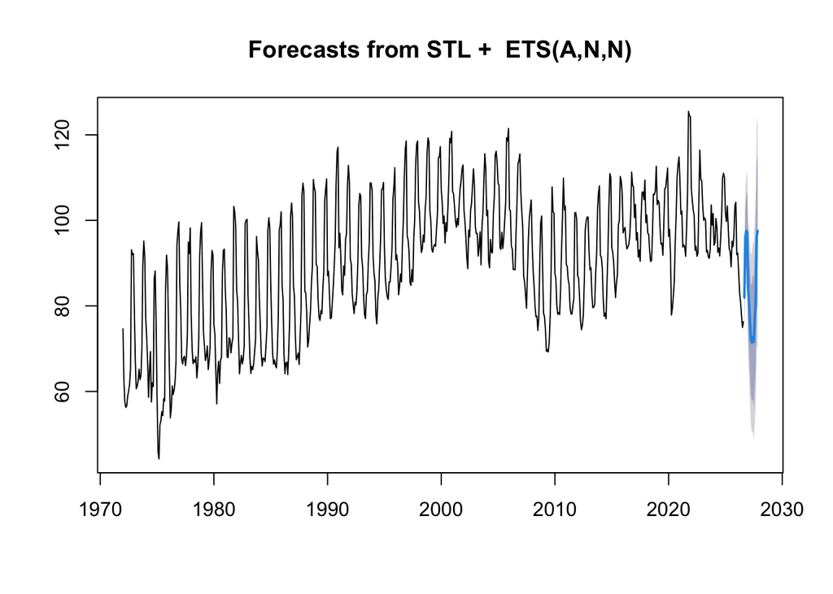

```r
plot(f_stl)
```

**Explanation:** Forecast on an STL object forecasts the seasonally adjusted series and then adds the seasonal pattern back in. By default it forecasts 24 months. With h=15 it forecasts 15 months, from September 2026 to November 2027.

Simple exponential smoothing has no trend, so the forecast assumes the level stays where it was in mid-2026, which is the lowest in more than a decade. That is why the forecast peaks are below every actual fall peak of the last ten years. If the recent drop turns out to be temporary, this forecast will be too low. If production keeps falling, it will be too high. The most recent months are also preliminary estimates that the Federal Reserve may revise.

## Decomposition

```r
decomp_candy <- decompose(candy_ts)
attributes(decomp_candy)
```

```
## $names
## [1] "x"        "seasonal" "trend"    "random"   "figure"   "type"
##
## $class
## [1] "decomposed.ts"
```

```r
seasadj(decomp_candy)
```

```
##            Jan       Feb       Mar       Apr       May       Jun       Jul
## 1972  72.52046  63.33542  63.28561  65.82067  66.72293  67.60939  69.97027
## 1973  77.37416  68.05792  66.39211  70.79947  72.52353  73.89049  72.58747
## 1974  75.11336  73.57642  73.01901  68.19427  75.06753  77.99009  67.36057
## 1975  56.32696  46.75152  49.98671  61.72247  63.16123  63.94989  64.15757
## 1976  74.25476  66.02962  59.58621  65.54517  71.35973  67.95989  70.12817
## 1977  83.01816  79.47912  73.31171  75.97037  78.06363  76.90619  75.86067
## 1978  76.16946  70.71362  72.27061  76.95217  76.88633  76.79299  72.99107
## 1979  83.84496  74.64872  76.40691  76.79807  78.36413  79.31549  74.96957
## 1980  73.56046  74.28882  70.62171  66.65997  74.84483  75.73419  71.70467
## 1981  81.80686  79.58602  73.76921  77.49917  82.63663  80.95089  78.83167
## 1982  81.58886  81.87492  78.20901  73.69807  76.69663  77.09839  76.27407
## 1983  80.72576  76.68112  73.66091  73.78567  75.90773  73.81009  76.32567
## 1984  79.63596  75.98082  74.51401  75.49877  77.93613  76.33509  76.81477
## 1985  82.94296  76.64252  74.69961  75.95037  77.44583  74.73619  75.32507
```

[output cut: 97 more lines]

**Explanation:** This is another way to split the series using moving averages. The results are close to STL. The monthly seasonal values have nearly the same peak in November and the same low in May. The seasonally adjusted values are also nearly identical.

## Summary

Decomposition shows that candy production is driven mainly by two things. The first being a long-run trend that follows the economy. It grew from the mid-1970s to about 2001, dropped sharply around the 2007 to 2009 recession, recovered through the 2010s, dipped in 2020, and has been falling since 2022. The second is that a strong and stable seasonal pattern is tied to the holiday calendar. The irregular component is small. An additive model fits the data because the seasonal swings did not grow as the level rose.